# Lake Okeechobee Sediment 2020/2021

Updated 2021-12-13 12:15:13

Provisional and preliminary results for the Lake Okeechobee 2020/2021 sediment sampling conducted by University of Florida.

# Sediment Zones

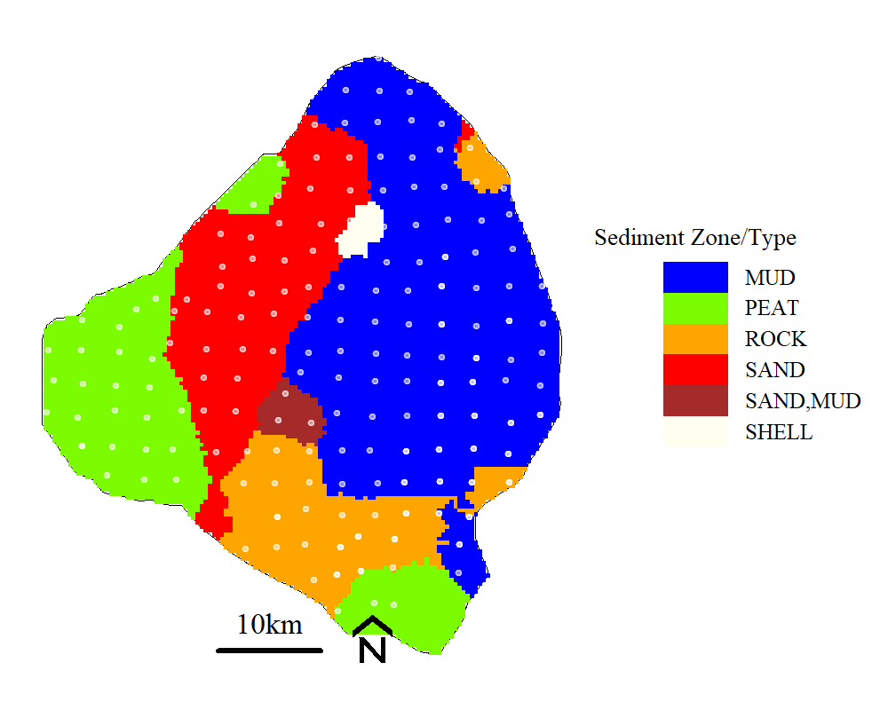

Sediment zones across Lake Okeechobee observed during the 2020/2021 sampling.

* Spatially interpolated using weighted k-nearest neighbor classifier with up to 10 nearest neighbots considered (i.e. k=10; `kknn` function in the `kknn` R-library).

# Mud Depth

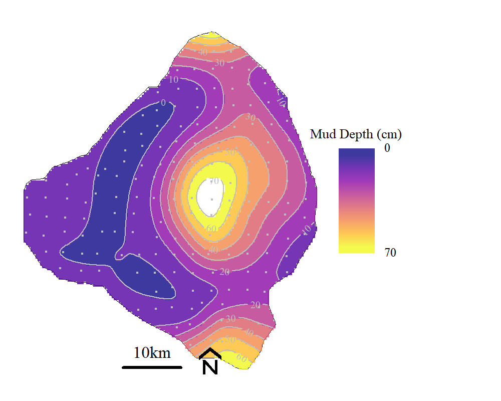

Mud depth across Lake Okeechobee observed during the 2020/2021 sampling.

* Spatially interpolated using tension spline (`Tps` function in the `fields` R-library).

# Bulk Density

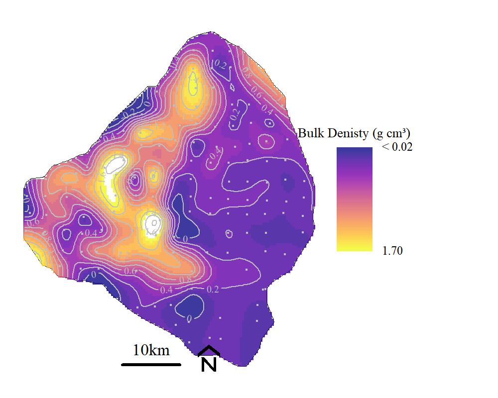

Bulk Density across Lake Okeechobee observed during the 2020/2021 sampling.

* Spatially interpolated using tension spline (`Tps` function in the `fields` R-library).

# Mineral Content

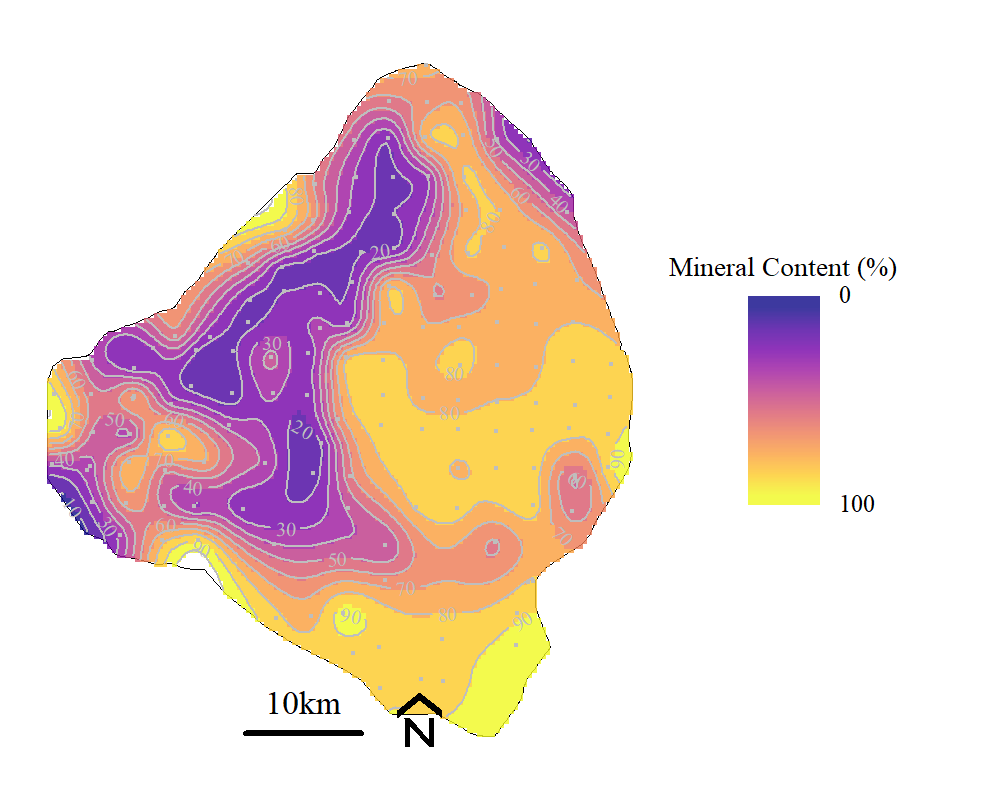

Mineral content across Lake Okeechobee observed during the 2020/2021 sampling.

* Spatially interpolated using tension spline (`Tps` function in the `fields` R-library).

# Total Phoshorus

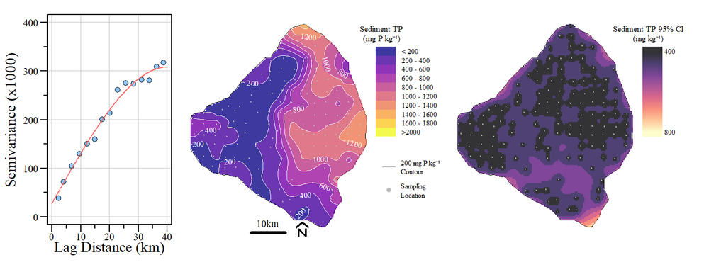

Total phosphorus across Lake Okeechobee observed during the 2020/2021 sampling including (left) semivariogram, (center) interpolated TP concentrations and (right) 95% Confience Interval interpolation.

Sediment total phosphorus kriging model fit results

| Model | Nugget | Sill | Range | sill.ratio | ME | rmse | r2 |
| --- | --- | --- | --- | --- | --- | --- | --- |
| Sph | 27758 | 308227 | 40077 | 91.0 | 878.85 | 3,523.26 | 1.00 |

# Inorganic Phoshorus (HCl TP)

- Data was log-transformed prior to variogram fitting.
- After kriging, the data were back-transformed consistent with Yamamoto (2007) and Journel (1980)

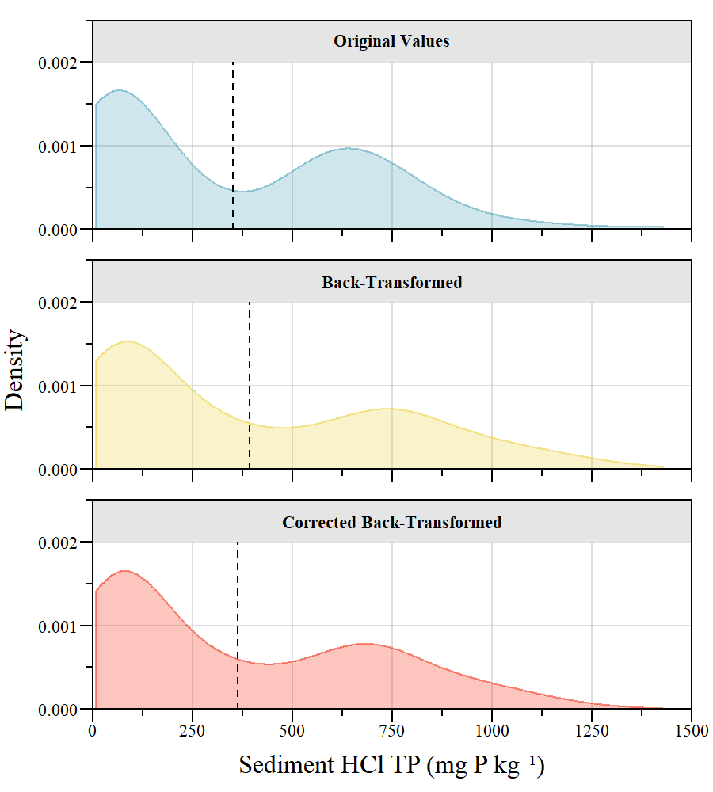

Comparison of original values, back-transformed and corrected back-transformed data.

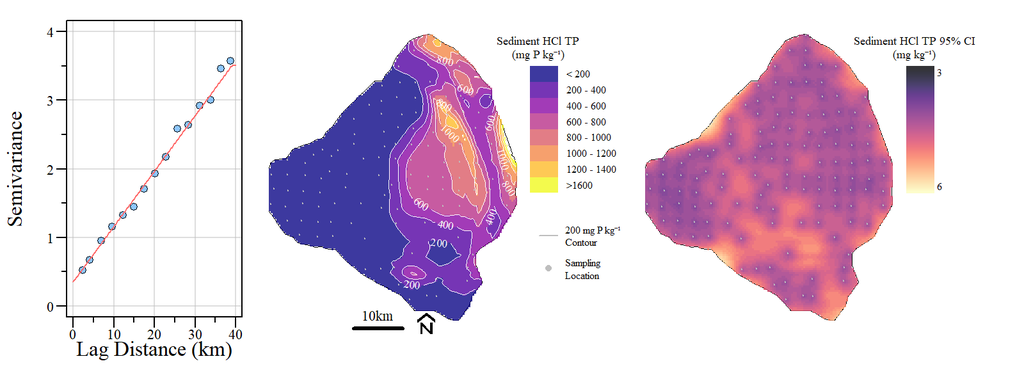

Inorganic phosphorus (HCl extracted) across Lake Okeechobee observed during the 2020/2021 sampling including (left) semivariogram, (center) interpolated TP concentrations and (right) 95% Confience Interval interpolation.

Sediment inorganic phosphorus kriging model fit results. Data were log-transformed to improve model fit.

| Model | Nugget | Sill | Range | sill.ratio | ME | rmse | r2 |
| --- | --- | --- | --- | --- | --- | --- | --- |
| Lin | 0.353 | 3.512 | 39113 | 89.9 | -0.011 | 0.04 | 1.00 |